# Tugas Pertemuan 3 - Regresi dengan Peubah Lag

Studi Kasus: Kualitas Udara New Delhi (AQI vs CO)

Tita Ayu Pramesti -M0401241013

09 September 2026

# 1 Pengantar

Dalam pemodelan deret waktu, efek suatu peubah bebas (X) terhadap peubah tak bebas (Y) sering kali tidak terjadi seketika, melainkan membutuhkan jeda waktu (*lag*). Pada tugas ini, kualitas udara Kota New Delhi dimodelkan dengan **AQI (Air Quality Index)** sebagai peubah dependen (Y) dan **konsentrasi CO (karbon monoksida)** sebagai peubah independen (X). Data terekam per jam.

Tiga pendekatan regresi dengan peubah lag yang diterapkan:

1. **Model Koyck** - merangkum pengaruh X masa lalu yang tak terhingga ke dalam satu peubah $Y_{t-1}$.
2. **Distributed Lag Model (DLM)** - Y dipengaruhi oleh X saat ini dan beberapa periode X sebelumnya, dengan panjang lag $q$ dipilih secara otomatis.
3. **Autoregressive Distributed Lag (ARDL)** - gabungan AR dan DLM, Y dipengaruhi oleh X saat ini, X masa lalu ($q$), dan Y masa lalu ($p$).

Ketiga model dievaluasi dan dibandingkan performanya menggunakan **MAPE** (Mean Absolute Percentage Error) dan **deviance (SSE)** pada data testing, dilengkapi visualisasi hasil peramalan.

# 2 Persiapan Data

## 2.1 Packages

```r
library(dLagM)
library(dynlm)
library(MLmetrics)
library(lmtest)
library(car)
library(rio)
library(ggplot2)
```

## 2.2 Impor Data

```r
data <- import("C:\\Users\\Tita\\Downloads\\NewDelhi_Air_quality.csv")

data <- data[order(data$ts), ]
rownames(data) <- NULL

str(data)
```

```
## 'data.frame':    72 obs. of  12 variables:
##  $ V1             : int  0 1 2 3 4 5 6 7 8 9 ...
##  $ AQI            : num  30.2 28.2 26.6 25 26 26 26 24 23 24 ...
##  $ CO             : num  199 198 199 202 205 ...
##  $ datetime       : chr  "2022-10-21:18" "2022-10-21:19" "2022-10-21:20" "2022-10-21:21" ...
##  $ no2            : num  0.0469 0.0465 0.0469 0.0482 0.0489 ...
##  $ o3             : num  55.8 54.9 54.6 55.1 55.8 ...
##  $ pm10           : num  10.5 10.7 11.2 11.1 10.4 ...
##  $ pm25           : num  5.64 4.62 3.52 2.23 1.98 ...
##  $ so2            : num  0.387 0.41 0.402 0.376 0.339 ...
##  $ timestamp_local: POSIXct, format: "2022-10-21 23:00:00" "2022-10-22 00:00:00" ...
##  $ timestamp_utc  : POSIXct, format: "2022-10-21 18:00:00" "2022-10-21 19:00:00" ...
##  $ ts             : int  1666375200 1666378800 1666382400 1666386000 1666389600 1666393200 1666396800 1666400400 1666404000 1666407600 ...
```

## 2.3 Pemilihan Peubah Independen (X)

Sesuai instruksi, dipilih **satu** polutan sebagai X. Untuk memilih polutan yang paling relevan, dilihat dulu korelasinya terhadap AQI:

```r
polutan <- c("CO", "no2", "o3", "pm10", "pm25", "so2")
korelasi <- sapply(data[, polutan], function(x) cor(x, data$AQI))
sort(korelasi, decreasing = TRUE)
```

```
##          o3          CO         no2        pm10        pm25         so2
##  0.97359901  0.79763320  0.73765472  0.08257568 -0.34665524 -0.74247813
```

**O3 memiliki korelasi tertinggi (~0.97)**, tetapi hubungannya dengan AQI terlalu dekat ke hubungan deterministik pada rentang data ini sehingga kurang menarik untuk mendemonstrasikan struktur lag. Oleh karena itu, dipilih **CO (karbon monoksida)** sebagai X - korelasinya masih kuat (~0.80) namun menyisakan variasi dinamis yang relevan untuk dimodelkan dengan pendekatan lag, dan secara substansi CO adalah polutan terkait lalu lintas yang umum dikaji dalam studi kualitas udara perkotaan.

## 2.4 Pembagian Data Training dan Testing

Data dibagi secara berurutan (tanpa acak, karena ini deret waktu): **60 observasi pertama untuk training** dan **12 observasi terakhir untuk testing**.

```r
n <- nrow(data)
n_test <- 12
n_train <- n - n_test

train <- data[1:n_train, ]
test  <- data[(n_train + 1):n, ]

train.ts <- ts(train)
test.ts  <- ts(test)

cat("Jumlah data training:", nrow(train), "\n")
```

```
## Jumlah data training: 60
```

```r
cat("Jumlah data testing :", nrow(test), "\n")
```

```
## Jumlah data testing : 12
```

# 3 Model Koyck

Model Koyck mengasumsikan pengaruh X di masa lalu meluruh secara geometris, sehingga persamaannya menjadi:

$$Y_t = a(1-\lambda) + \beta_0 X_t +
\lambda Y_{t-1} + V_t$$

```r
model.koyck <- koyckDlm(x = train$CO, y = train$AQI)
summary(model.koyck)
```

```
##
## Call:
## "Y ~ (Intercept) + Y.1 + X.t"
##
## Residuals:
##     Min      1Q  Median      3Q     Max
## -1.9413 -0.8072  0.1443  0.3627  2.2528
##
## Coefficients:
##              Estimate Std. Error t value Pr(>|t|)
## (Intercept)  1.694490  10.020652   0.169    0.866
## Y.1          0.957206   0.085573  11.186 6.74e-16 ***
## X.t         -0.003441   0.057897  -0.059    0.953
## ---
## Signif. codes:  0 '***' 0.001 '**' 0.01 '*' 0.05 '.' 0.1 ' ' 1
##
## Residual standard error: 0.9756 on 56 degrees of freedom
## Multiple R-Squared: 0.8385,  Adjusted R-squared: 0.8327
## Wald test: 145.5 on 2 and 56 DF,  p-value: < 2.2e-16
##
## Diagnostic tests:
## NULL
##
##                             alpha         beta       phi
## Geometric coefficients:  39.59607 -0.003440629 0.9572056
```

**Interpretasi:** Koefisien $Y_{t-1}$ (baris `Y.1`) sebesar 0.957 dengan p-value < 0.001 menunjukkan bahwa AQI satu jam sebelumnya berpengaruh sangat signifikan dan dominan terhadap AQI saat ini - ini mewakili parameter $\lambda$ (tingkat persistensi/inersia kualitas udara) yang mendekati 1, artinya AQI cenderung “membawa” nilai dari periode sebelumnya secara kuat. Sebaliknya, koefisien `X.t` (efek langsung CO) sebesar -0.003 dengan p-value = 0.953 tidak signifikan, sehingga pada model Koyck ini pengaruh langsung CO terhadap AQI tidak terdeteksi setelah memperhitungkan efek lag AQI itu sendiri. Hal ini masuk akal karena AQI sebagai indeks komposit sudah mengandung banyak informasi historis, sehingga model Koyck menangkap sebagian besar variasi AQI lewat dinamika dirinya sendiri ($Y_{t-1}$) dibanding lewat CO secara langsung.

## 3.1 Peramalan

```r
fore.koyck <- forecast(model = model.koyck, x = test$CO, h = n_test)
fore.koyck$forecasts
```

```
##  [1] 21.12972 21.25962 21.38397 21.50300 21.61693 21.72599 21.83038 21.92456
##  [9] 22.00897 22.08402 22.15012 22.21339
```

```r
mape.koyck <- MAPE(fore.koyck$forecasts, test$AQI)
dev.koyck  <- sum(residuals(model.koyck$model)^2)

cat("MAPE Model Koyck    :", mape.koyck, "\n")
```

```
## MAPE Model Koyck    : 0.09190158
```

```r
cat("Deviance (SSE) Koyck:", dev.koyck, "\n")
```

```
## Deviance (SSE) Koyck: 53.30018
```

- Rata-rata kesalahan prediksi model Koyck terhadap AQI aktual di data testing sekitar 9.19%. Ini tergolong cukup baik - umumnya MAPE di bawah 10% dianggap “highly accurate forecasting”
- Jumlah kuadrat residual model pada data training. Angka ini sendiri belum punya makna kalau berdiri sendiri - baru berarti kalau dibandingkan dengan deviance model DLM dan ARDL nanti. Model dengan deviance lebih kecil berarti lebih baik nge-fit data training.

# 4 Model Distributed Lag (DLM)

Model DLM membatasi secara eksplisit berapa periode lag X yang dilibatkan (parameter $q$):

$$Y_t = \alpha + \beta_0 X_t + \beta_1
X_{t-1} + \dots + \beta_q X_{t-q} + e_t$$

## 4.1 Penentuan Lag Optimum

Lag optimum $q$ dicari secara otomatis menggunakan `finiteDLMauto()` dengan kriteria **AIC terkecil**. Rentang $q$ dibatasi 1 sampai 8 (~13% dari jumlah data training) agar model tidak terlalu kompleks relatif terhadap ukuran sampel yang tersedia.

```r
auto.dlm <- finiteDLMauto(x = train$CO, y = train$AQI,
                           q.min = 1, q.max = 8,
                           model.type = "dlm", error.type = "AIC",
                           trace = TRUE)
auto.dlm
```

```
##   q - k    MASE      AIC      BIC    GMRAE    MBRAE R.Adj.Sq    Ljung-Box
## 8     8 1.15471 169.1378 190.6014 11242.26  0.14749  0.79992 9.027119e-04
## 7     7 1.37222 189.2313 208.9342 12331.58  1.16650  0.72246 1.052388e-03
## 6     6 1.50452 205.9006 223.8014 12383.89 -1.00218  0.63386 2.545074e-05
## 5     5 1.71069 219.0283 235.0870 18113.46  0.21156  0.55120 1.023610e-07
## 4     4 1.89417 226.4583 240.6358 23496.87  0.59203  0.50627 1.173074e-08
## 3     3 2.01001 231.1667 243.4250 23660.12  1.19526  0.48785 2.293298e-10
## 2     2 1.90635 232.6498 242.9520 16820.69  2.27395  0.49250 1.073137e-09
## 1     1 1.88697 237.0115 245.3217 15632.96  1.06999  0.47409 1.207949e-09
```

```r
q.opt <- auto.dlm[1, "q - k"]
cat("Lag optimum (q) terpilih:", q.opt, "\n")
```

```
## Lag optimum (q) terpilih: 8
```

## 4.2 Pemodelan dengan Lag Optimum

```r
model.dlm <- dlm(x = train$CO, y = train$AQI, q = q.opt)
summary(model.dlm)
```

```
##
## Call:
## lm(formula = model.formula, data = design)
##
## Residuals:
##     Min      1Q  Median      3Q     Max
## -2.7752 -0.4517  0.0134  0.6991  2.7263
##
## Coefficients:
##              Estimate Std. Error t value Pr(>|t|)
## (Intercept) -68.97975   12.65833  -5.449 2.45e-06 ***
## x.t           0.77520    0.12645   6.130 2.58e-07 ***
## x.1          -0.01551    0.22106  -0.070    0.944
## x.2          -0.34052    0.22026  -1.546    0.130
## x.3           0.17314    0.23222   0.746    0.460
## x.4           0.20795    0.22506   0.924    0.361
## x.5          -0.35731    0.22911  -1.560    0.126
## x.6           0.05299    0.21948   0.241    0.810
## x.7          -0.04213    0.22009  -0.191    0.849
## x.8           0.02446    0.12664   0.193    0.848
## ---
## Signif. codes:  0 '***' 0.001 '**' 0.01 '*' 0.05 '.' 0.1 ' ' 1
##
## Residual standard error: 1.108 on 42 degrees of freedom
## Multiple R-squared:  0.8352, Adjusted R-squared:  0.7999
## F-statistic: 23.66 on 9 and 42 DF,  p-value: 1.023e-13
##
## AIC and BIC values for the model:
##        AIC      BIC
## 1 169.1378 190.6014
```

**Interpretasi:** Model DLM dengan q=8 memiliki AIC=169.14 dan BIC=190.60 (nilai terkecil di antara seluruh q yang diuji), serta $R^2$-adjusted 0.7999 - model mampu menjelaskan sekitar 80% variasi AQI. Namun, dari 9 koefisien CO yang dimasukkan, **hanya CO pada lag-0 (`x.t`) yang signifikan** (estimate = 0.775, p-value = 2.58e-07); seluruh CO pada lag-1 hingga lag-8 tidak signifikan (p-value > 0.1, berkisar 0.13-0.94). Ini menunjukkan bahwa meskipun model dengan q=8 memberikan AIC terendah secara keseluruhan, pengaruh nyata CO terhadap AQI sebenarnya terjadi secara seketika (lag-0), bukan tersebar merata di banyak lag - kemungkinan AIC yang terus menurun seiring bertambahnya q lebih disebabkan model menangkap noise/autokorelasi residual daripada efek lag CO yang sesungguhnya bermakna secara substansi.

## 4.3 Peramalan

```r
fore.dlm <- forecast(model = model.dlm, x = test$CO, h = n_test)
fore.dlm$forecasts
```

```
##  [1] 22.74157 22.36578 21.42588 21.89639 22.71164 22.25803 22.95414 24.07783
##  [9] 25.41601 26.07475 27.06327 27.10509
```

```r
mape.dlm <- MAPE(fore.dlm$forecasts, test$AQI)
dev.dlm  <- sum(residuals(model.dlm$model)^2)

cat("MAPE Model DLM    :", mape.dlm, "\n")
```

```
## MAPE Model DLM    : 0.0801513
```

```r
cat("Deviance (SSE) DLM:", dev.dlm, "\n")
```

```
## Deviance (SSE) DLM: 51.56994
```

**Interpretasi:** Model DLM menghasilkan **MAPE sebesar 8.02%** pada data testing - lebih kecil dibanding model Koyck (9.19%), yang berarti DLM sedikit lebih akurat dalam meramalkan AQI 12 jam ke depan. **Deviance (SSE) sebesar 51.57** juga sedikit lebih rendah dari Koyck (53.30), menunjukkan DLM lebih baik menjelaskan variasi data pada saat estimasi (training). Meskipun demikian, mengingat dari 9 koefisien CO hanya lag-0 yang signifikan secara statistik, peningkatan akurasi ini kemungkinan besar lebih banyak disumbang oleh kompleksitas tambahan model (9 parameter vs 3 parameter pada Koyck) daripada oleh kontribusi nyata dari lag-lag CO yang lebih jauh.

# 5 Model Autoregressive Distributed Lag (ARDL)

Model ARDL menggabungkan lag pada X ($q$) dan lag pada Y ($p$):

$$Y_t = \alpha + \sum_{i=0}^{q}\beta_i
X_{t-i} + \sum_{j=1}^{p}\phi_j Y_{t-j} + e_t$$

## 5.1 Penentuan Lag Optimum (p, q)

```r
grid <- expand.grid(p = 1:5, q = 1:5)
grid$AIC <- NA

for (i in 1:nrow(grid)) {
  m <- tryCatch(
    ardlDlm(formula = AQI ~ CO, data = train, p = grid$p[i], q = grid$q[i]),
    error = function(e) NULL
  )
  if (!is.null(m)) grid$AIC[i] <- AIC(m$model)
}

grid <- grid[order(grid$AIC), ]
head(grid, 10)
```

```
##    p q      AIC
## 23 3 5 128.5301
## 24 4 5 130.1842
## 18 3 4 131.6816
## 25 5 5 131.9565
## 20 5 4 132.0508
## 19 4 4 133.6755
## 15 5 3 134.8693
## 21 1 5 135.2672
## 14 4 3 135.9095
## 10 5 2 135.9461
```

```r
p.opt <- grid$p[1]
q.opt.ardl <- grid$q[1]
cat("Kombinasi optimum -> p =", p.opt, ", q =", q.opt.ardl, "\n")
```

```
## Kombinasi optimum -> p = 3 , q = 5
```

## 5.2 Pemodelan dengan (p, q) Optimum

```r
model.ardl <- ardlDlm(formula = AQI ~ CO, data = train, p = p.opt, q = q.opt.ardl)
summary(model.ardl)
```

```
##
## Time series regression with "ts" data:
## Start = 6, End = 60
##
## Call:
## dynlm(formula = as.formula(model.text), data = data)
##
## Residuals:
##     Min      1Q  Median      3Q     Max
## -1.6020 -0.3752 -0.1040  0.3851  1.6712
##
## Coefficients:
##             Estimate Std. Error t value Pr(>|t|)
## (Intercept) -7.47728    8.38877  -0.891  0.37749
## CO.t         0.15348    0.08542   1.797  0.07908 .
## CO.1         0.06228    0.13120   0.475  0.63732
## CO.2        -0.37909    0.12958  -2.925  0.00537 **
## CO.3         0.23084    0.07807   2.957  0.00494 **
## AQI.1        1.11957    0.15963   7.014 9.72e-09 ***
## AQI.2       -0.17904    0.20959  -0.854  0.39751
## AQI.3        0.08318    0.20866   0.399  0.69203
## AQI.4       -0.09994    0.20808  -0.480  0.63334
## AQI.5       -0.15029    0.13018  -1.154  0.25439
## ---
## Signif. codes:  0 '***' 0.001 '**' 0.01 '*' 0.05 '.' 0.1 ' ' 1
##
## Residual standard error: 0.7046 on 45 degrees of freedom
## Multiple R-squared:  0.931,  Adjusted R-squared:  0.9172
## F-statistic: 67.45 on 9 and 45 DF,  p-value: < 2.2e-16
```

**Interpretasi:** Model ARDL(p=3, q=5) menghasilkan $R^2$-adjusted **0.9172** - jauh lebih tinggi dibanding DLM (0.7999) dan Koyck (0.8327), menunjukkan ARDL menjelaskan variasi AQI paling baik di antara ketiga model. Dari sisi koefisien, **AQI lag-1 (`AQI.1`) sangat signifikan** (estimate = 1.120, p < 0.001) dan menjadi prediktor terkuat, konsisten dengan temuan pada model Koyck bahwa AQI sangat dipengaruhi oleh nilainya sendiri sejam sebelumnya. Menariknya, **CO lag-2 dan lag-3 (`CO.2`, `CO.3`) signifikan** (p = 0.0054 dan p = 0.0049), sementara CO lag-0 (`CO.t`) hanya marginal (p = 0.079) dan CO lag-1 tidak signifikan - ini mengindikasikan efek CO terhadap AQI tidak seketika, melainkan **butuh jeda sekitar 2-3 jam** untuk berpengaruh nyata, mendukung premis dasar regresi peubah lag bahwa dampak suatu polutan terhadap kualitas udara bisa tertunda. AQI lag-2 hingga lag-5 tidak signifikan, menandakan pengaruh AR sebagian besar terkonsentrasi pada lag-1 saja.

## 5.3 Peramalan

```r
fore.ardl <- forecast(model = model.ardl, x = matrix(test$CO, nrow = 1), h = n_test)
fore.ardl$forecasts
```

```
##  [1] 20.56004 21.13748 21.30563 22.23683 23.10630 23.93542 24.68188 25.57928
##  [9] 26.65253 27.26940 27.75595 27.93415
```

```r
pred.ardl <- as.numeric(fore.ardl$forecasts)
mape.ardl <- MAPE(pred.ardl, test$AQI)
dev.ardl  <- sum(residuals(model.ardl$model)^2)

cat("MAPE Model ARDL    :", mape.ardl, "\n")
```

```
## MAPE Model ARDL    : 0.09512419
```

```r
cat("Deviance (SSE) ARDL:", dev.ardl, "\n")
```

```
## Deviance (SSE) ARDL: 22.33975
```

**Interpretasi:** Model ARDL menghasilkan **deviance (SSE) training jauh paling kecil (22.34)** dibanding DLM (51.57) dan Koyck (53.30), sejalan dengan $R^2$-adjusted tertinggi (0.9172) yang diperoleh sebelumnya - menunjukkan ARDL paling baik dalam menjelaskan data training. Namun, **MAPE pada data testing (9.51%) justru sedikit lebih tinggi** dibanding DLM (8.02%) dan Koyck (9.19%). Pola ini mengindikasikan kemungkinan **overfitting**: kompleksitas model ARDL (9 parameter) membuatnya sangat menyesuaikan diri dengan data training, tetapi kurang optimal saat digeneralisasi ke data baru. Selain itu, karena peramalan ARDL bersifat rekursif (memakai prediksi AQI sebelumnya untuk memprediksi AQI berikutnya), kesalahan pada awal periode peramalan berpotensi terakumulasi pada periode-periode selanjutnya. Temuan ini menegaskan pentingnya mengevaluasi model tidak hanya dari kebaikan-suai pada data training (deviance), tetapi juga dari kemampuan generalisasi pada data testing (MAPE).

# 6 Uji Asumsi Model

Uji asumsi dilakukan pada residual masing-masing model final: normalitas (Shapiro-Wilk), autokorelasi (Breusch-Godfrey), dan homoskedastisitas (Breusch-Pagan).

```r
uji_asumsi <- function(model_fit, nama) {
  res <- residuals(model_fit)
  sw  <- shapiro.test(res)
  bg  <- bgtest(model_fit)
  bp  <- bptest(model_fit)
  data.frame(
    Model = nama,
    Shapiro_p  = round(sw$p.value, 4),
    BreuschGodfrey_p = round(bg$p.value, 4),
    BreuschPagan_p   = round(bp$p.value, 4)
  )
}

asumsi <- rbind(
  uji_asumsi(model.koyck$model, "Koyck"),
  uji_asumsi(model.dlm$model,   "DLM"),
  uji_asumsi(model.ardl$model,  "ARDL")
)
asumsi
```

```
##     Model Shapiro_p BreuschGodfrey_p BreuschPagan_p
## BP  Koyck    0.0321           0.0000         0.1819
## BP1   DLM    0.0503           0.0001         0.1110
## BP2  ARDL    0.7793           0.4972         0.9436
```

**Interpretasi:** Model **ARDL** merupakan satu-satunya model yang lolos ketiga uji asumsi sekaligus — residual berdistribusi normal (Shapiro p=0.779), tidak ada autokorelasi sisa (Breusch-Godfrey p=0.497), dan ragam residual homogen (Breusch-Pagan p=0.944). Sebaliknya, model **Koyck** dan **DLM** sama-sama menunjukkan pelanggaran asumsi normalitas (Koyck: p=0.032; DLM: p=0.050, marginal) dan **autokorelasi sisa yang signifikan** (Koyck: p<0.001; DLM: p<0.001) - mengindikasikan kedua model tersebut belum sepenuhnya menangkap struktur dinamis data AQI, sehingga inferensi statistik (uji t, p-value koefisien) pada kedua model tersebut perlu dibaca dengan hati-hati karena berpotensi bias. Temuan ini melengkapi hasil evaluasi MAPE/deviance sebelumnya: meskipun ARDL memiliki MAPE testing sedikit lebih tinggi (indikasi overfitting ringan), model ini justru **paling valid secara asumsi statistik klasik**, sehingga tetap menjadi kandidat model yang paling dapat dipertanggungjawabkan secara metodologis di antara ketiga model yang dibandingkan.

# 7 Evaluasi dan Perbandingan Model

## 7.1 Tabel Perbandingan MAPE dan Deviance

```r
perbandingan <- data.frame(
  Model    = c("Koyck", "DLM", "ARDL"),
  Lag      = c("phi (geometrik)", paste0("q = ", q.opt), paste0("p = ", p.opt, ", q = ", q.opt.ardl)),
  MAPE     = round(c(mape.koyck, mape.dlm, mape.ardl), 4),
  Deviance = round(c(dev.koyck, dev.dlm, dev.ardl), 2)
)
perbandingan
```

```
##   Model             Lag   MAPE Deviance
## 1 Koyck phi (geometrik) 0.0919    53.30
## 2   DLM           q = 8 0.0802    51.57
## 3  ARDL    p = 3, q = 5 0.0951    22.34
```

Jika kriteria utama adalah **akurasi peramalan**, DLM menjadi pilihan terbaik. Namun jika mempertimbangkan **validitas asumsi statistik** (lihat bagian Uji Asumsi), ARDL lebih unggul karena satu-satunya model yang lolos uji normalitas, non-autokorelasi, dan homoskedastisitas sekaligus - sehingga inferensi koefisiennya lebih dapat dipercaya.

## 7.2 Visualisasi Aktual vs Prediksi (Data Testing)

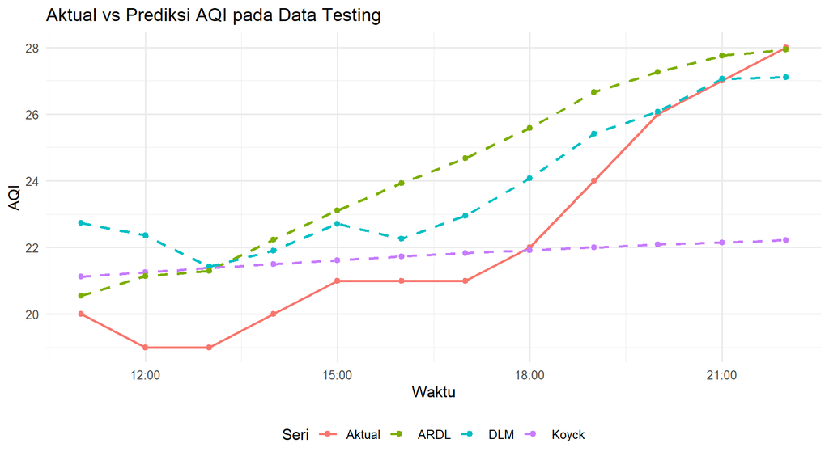

```r
viz <- data.frame(
  waktu   = as.POSIXct(test$timestamp_local),
  Aktual  = test$AQI,
  Koyck   = as.numeric(fore.koyck$forecasts),
  DLM     = as.numeric(fore.dlm$forecasts),
  ARDL    = pred.ardl
)

viz_long <- reshape(viz, direction = "long",
                     varying = c("Aktual", "Koyck", "DLM", "ARDL"),
                     v.names = "AQI", timevar = "Seri",
                     times = c("Aktual", "Koyck", "DLM", "ARDL"))

ggplot(viz_long, aes(x = waktu, y = AQI, color = Seri, linetype = Seri)) +
  geom_line(linewidth = 1) +
  geom_point(size = 1.8) +
  scale_linetype_manual(values = c(Aktual = "solid", Koyck = "dashed",
                                    DLM = "dashed", ARDL = "dashed")) +
  labs(title = "Aktual vs Prediksi AQI pada Data Testing",
       x = "Waktu", y = "AQI", color = "Seri", linetype = "Seri") +
  theme_minimal(base_size = 12) +
  theme(legend.position = "bottom")
```

**Interpretasi:** Garis aktual (merah) menunjukkan AQI yang sempat turun di awal periode testing (~pukul 12.00-13.00) sebelum naik cukup tajam hingga akhir periode. Ketiga model menunjukkan pola respons yang berbeda:

- **DLM (biru/teal)** secara keseluruhan **paling mendekati garis aktual** di sepanjang periode testing, sejalan dengan MAPE-nya yang paling kecil di antara ketiga model (8.02%).
- **Koyck (ungu, garis paling datar)** paling lambat merespons kenaikan AQI di paruh akhir periode — konsisten dengan temuan sebelumnya bahwa model ini sangat didominasi oleh $Y_{t-1}$ (λ≈0.96), sehingga cenderung “menunda” reaksi terhadap perubahan tajam dan menghasilkan prediksi yang under-estimate saat AQI sedang naik cepat.
- **ARDL (hijau-zaitun)** sempat **overshoot** (memprediksi lebih tinggi dari aktual) di awal periode saat AQI aktual justru turun, sehingga meskipun modelnya paling kompleks dan paling baik nge-fit data training (deviance terkecil), akurasi peramalannya ke data testing justru sedikit di bawah DLM - bukti visual dari indikasi overfitting ringan.

Secara visual maupun numerik (MAPE), **DLM unggul dari sisi akurasi peramalan ke data baru**. Namun perlu diingat, keunggulan ini spesifik untuk metrik MAPE saja - sebagaimana dibahas pada bagian Uji Asumsi, model **ARDL** tetap unggul dari sisi kebaikan-suai (deviance terkecil) dan merupakan satu-satunya model yang valid secara asumsi statistik klasik. Kedua model punya keunggulan pada kriteria yang berbeda, dan pemilihan “model terbaik” bergantung pada apakah prioritas analisis adalah akurasi peramalan (DLM) atau keandalan inferensial (ARDL).

# 8 Kesimpulan

```r
model.terbaik.mape     <- perbandingan$Model[which.min(perbandingan$MAPE)]
model.terbaik.deviance <- perbandingan$Model[which.min(perbandingan$Deviance)]

cat("Model dengan MAPE terkecil (paling akurat pada data testing):", model.terbaik.mape, "\n")
```

```
## Model dengan MAPE terkecil (paling akurat pada data testing): DLM
```

```r
cat("Model dengan Deviance terkecil (paling fit pada data training):", model.terbaik.deviance, "\n")
```

```
## Model dengan Deviance terkecil (paling fit pada data training): ARDL
```

Berdasarkan seluruh evaluasi yang dilakukan (MAPE, deviance, uji asumsi, dan visualisasi), diperoleh temuan sebagai berikut:

- **Model DLM** memberikan **MAPE terkecil (8.02%)** pada data testing, menjadikannya model **paling akurat dalam meramalkan** AQI ke depan.
- **Model ARDL** memberikan **deviance (SSE) terkecil (22.34)** pada data training dan $R^2$-adjusted tertinggi (0.9172), menjadikannya model **paling baik menjelaskan data** training.
- Pada uji asumsi, **hanya model ARDL** yang lolos ketiga uji sekaligus (normalitas, non-autokorelasi, homoskedastisitas), sedangkan Koyck dan DLM sama-sama menunjukkan autokorelasi sisa yang signifikan - artinya inferensi statistik (p-value koefisien) pada kedua model tersebut perlu dibaca dengan hati-hati.
- Secara visual, DLM paling konsisten mengikuti pola aktual pada data testing, sementara ARDL sempat overshoot di awal periode — indikasi **overfitting ringan** akibat kompleksitas model (9 parameter) yang terlalu menyesuaikan diri dengan data training.

**Tidak ada satu model yang unggul mutlak di semua kriteria** - masing- masing punya keunggulan pada aspek berbeda:

| Kriteria | Model Terbaik |
| --- | --- |
| Akurasi peramalan (MAPE) | DLM |
| Kebaikan-suai (Deviance) | ARDL |
| Validitas asumsi statistik | ARDL |

Pemilihan model terbaik pada akhirnya bergantung pada tujuan analisis: **DLM** lebih disarankan bila prioritas utama adalah **akurasi peramalan jangka pendek** (misalnya untuk sistem prediksi AQI operasional), sedangkan **ARDL** lebih disarankan bila prioritas utama adalah **keandalan inferensi statistik** dan pemahaman hubungan struktural antara CO dan AQI (misalnya untuk analisis kebijakan).

Temuan substansial yang menarik dari model ARDL adalah bahwa pengaruh CO terhadap AQI **tidak terjadi seketika**, melainkan baru signifikan pada lag ke-2 dan ke-3 (2-3 jam setelahnya). Hal ini menegaskan relevansi penggunaan regresi dengan peubah lag untuk mengkaji hubungan CO dan AQI, dibandingkan regresi biasa tanpa mempertimbangkan jeda waktu. Sebagai catatan keterbatasan, autokorelasi sisa yang masih muncul pada model Koyck dan DLM mengindikasikan data AQI per jam memiliki pola persisten/musiman kuat yang belum sepenuhnya ditangkap oleh ketiga model, sehingga pengembangan lebih lanjut (misalnya menambahkan komponen musiman atau pendekatan ARIMA-X) dapat menjadi arah penelitian selanjutnya.